# 知乎热榜问题爬虫

author: Chunkit Woo

## 爬取热榜榜单

### 利用 web_scraper 获取标题和热度

```python
import pandas as pd
```

```python
hot_df = pd.read_csv('zhihu_hot.csv')
```

```python
hot_df = hot_df.sort_values(by='web-scraper-order').reset_index(drop=True)
hot_df = hot_df.drop(['web-scraper-order','web-scraper-start-url'],axis=1)
```

```python
hot_df.columns=['标题','热度（万）']
```

```python
hot_df['热度（万）']=hot_df['热度（万）'].str.split('万').str[0]
```

```python
hot_df.head()
```

|  | 标题 | 热度（万） |
| --- | --- | --- |
| 0 | 全国新冠肺炎情况怎么样了？ | 置顶 |
| 1 | 1992 年南医大女生被杀案告破，此案难点在哪？为何需要 28 年才抓到凶手？ | 10981 |
| 2 | 如何看待韩国民众不顾疫情禁令举行大型集会，首尔市长劝市民解散遭围攻？新冠肺炎在海外为何难以引... | 4380 |
| 3 | 猫可以傻到什么程度？ | 2895 |
| 4 | 你认为哪个大学的校徽颜值最高？ | 2053 |

### 利用request+beautiful获取标题和热度

```python
import requests
from bs4 import BeautifulSoup
import pandas as pd
import numpy as np
```

```python
url = 'https://www.zhihu.com/billboard'
```

```python
headers = {
'Host':'www.zhihu.com',
'User-Agent': 'Mozilla/5.0 (Windows NT 10.0; Win64; x64) AppleWebKit/537.36 (KHTML, like Gecko) Chrome/76.0.3809.87 Safari/537.36',
}
```

```python
response = requests.get(url,headers=headers)
```

```python
soup = BeautifulSoup(response.content,'lxml')
```

```python
soup.find('div',class_='HotList-itemTitle')
```

```
<div class="HotList-itemTitle">《唐探 3》为什么秦风没有加入 Q？Q 的目的是什么？</div>
```

```python
#Title lists
Title_lists = soup.find_all('div',class_='HotList-itemTitle')
```

```python
# Metrics_lists
Metrics_lists = soup.find_all('div',class_='HotList-itemMetrics')
```

```python
#data
data = pd.concat([pd.Series(data=Title_lists),(pd.Series(data=Metrics_lists))],axis=1)
```

```python
data.head()
```

|  | 0 | 1 |
| --- | --- | --- |
| 0 | [《唐探 3》为什么秦风没有加入 Q？Q 的目的是什么？] | [3052 万热度] |
| 1 | [《你好，李焕英》为什么贾玲意识到妈妈那时还不会在补丁上绣花时突然崩溃？] | [1634 万热度] |
| 2 | [《唐探三》是不是被有些人故意恶评了？] | [1541 万热度] |
| 3 | [打扫卫生的阿姨弄坏了我的手办，我希望她赔钱，我爸说我咄咄逼人，请问我做错了吗?] | [1305 万热度] |
| 4 | [《你好，李焕英》真的适合带爸妈看吗？会不会只是自己以为的适合？] | [909 万热度] |

```python
data = data.applymap(lambda x: x.get_text())
```

```python
data.columns=['标题','热度（万）']
```

```python
data['热度（万）']=data['热度（万）'].str.split('万').str[0]
```

```python
data.head()
```

|  | 标题 | 热度（万） |
| --- | --- | --- |
| 0 | 《唐探 3》为什么秦风没有加入 Q？Q 的目的是什么？ | 3052 |
| 1 | 《你好，李焕英》为什么贾玲意识到妈妈那时还不会在补丁上绣花时突然崩溃？ | 1634 |
| 2 | 《唐探三》是不是被有些人故意恶评了？ | 1541 |
| 3 | 打扫卫生的阿姨弄坏了我的手办，我希望她赔钱，我爸说我咄咄逼人，请问我做错了吗? | 1305 |
| 4 | 《你好，李焕英》真的适合带爸妈看吗？会不会只是自己以为的适合？ | 909 |

因为时间差，具体的热度值会有差别。因为request+beautiful的数据是更近更新的额，所以我们取request+beautiful方式获得的数据。

### 利用request+beautiful获取热榜类别

```python
from lxml import etree  # lxml 是python一个用来读写HTML和XML格式数据的库，可以高效而且可靠的解析大文件
import requests

url = "https://www.zhihu.com/hot"

headers = {
    'User-Agent': 'Mozilla/5.0 (Windows NT 10.0; Win64; x64) AppleWebKit/537.36 (KHTML, like Gecko) Chrome/76.0.3809.87 Safari/537.36'
    , #这个comma不能漏，否则invalid syntax
    'cookie':'_zap=cae731eb-ab1f-4c5c-89ca-53ea1eee2b1c; _xsrf=e8b6f619-0cd9-450e-bf49-968468403216; d_c0="APBZVCS9kBGPTpt5OC3J1TEpT-Gq8nhI6Wo=|1594551034"; _ga=GA1.2.1182192530.1594551036; tshl=; tst=h; q_c1=9071544c7b1645f3a40569c8c50df6ed|1613287267000|1613287267000; captcha_session_v2="2|1:0|10:1613289590|18:captcha_session_v2|28:YzBrZGd0bXYzanZqa3VzamVzMTA=|e4accbaeb1f6426f21937ebf295642113da842fe5da3bcce37f878cefa4dfe5b"; captcha_ticket_v2="2|1:0|10:1613289615|17:captcha_ticket_v2|228:eyJhcHBpZCI6IjIwMTIwMzEzMTQiLCJyZXQiOjAsInRpY2tldCI6InQwM2Jt…=|fb6f2eaff3e2a85ee1ed1b71c8144d3f0525f2777d1f02605dfde23b8fbeb67d"; z_c0="2|1:0|10:1613289616|4:z_c0|92:Mi4xRjNQMkFBQUFBQUFBOEZsVUpMMlFFU1lBQUFCZ0FsVk5rQ1lXWVFCVGNXOTJLY3JJTHlQY1dMRGVRZVFFZnBNLUxB|d66518ffe955d710252c03db9873267cd44ca88a30fa60dd8f60e89a07309efd"; Hm_lvt_98beee57fd2ef70ccdd5ca52b9740c49=1613284087,1613288247,1613288521,1613290071; Hm_lpvt_98beee57fd2ef70ccdd5ca52b9740c49=1613290071; SESSIONID=VNlM3dBwU4YYxMH45JrjL1uEZGB7Odq2SjAnBJrBf2u; KLBRSID=37f2e85292ebb2c2ef70f1d8e39c2b34|1613290073|1613283738; JOID=UV8cBkm_BasA8kQ9TrlgeQ3D_6hV7UXLSsAkcTXrNfxVjQhxdOzdiGb3Tj9FOa80O-Q_FLssbvO4DSDyhye3N4o=; osd=UlkXBUy8A6AD90c7RbplegvI_K1W607IT8MiejbuNvpejg1ycufejWXxRTxAOqk_OOE8ErAva_C-BiP3hCG8NI8='
}

response = requests.get(url, headers = headers)
html_str = response.content.decode()
html = etree.HTML(html_str)
```

```python
ret = html.xpath('//section[@class="HotItem"]')
# 双斜杠 // ： 在当前标签下所有子级中搜索； 单斜杠 / ： 在这个标签下一层中搜索
# html section 标签用于定义文档中的节（section、区段）
# @的作用: 表示属性，div属于标签，它有自己的属性，例如class，id
# . 选取当前节点
```

```python
itemlist = []
for table in ret:
    item = {}
    item['排名'] = table.xpath(".//div[@class='HotItem-index']/div/text()")
    item['标题'] = table.xpath(".//div[@class='HotItem-content']/a/@title")
    item['热度（万）'] = table.xpath(".//div[@class='HotItem-metrics HotItem-metrics--bottom']/text()")
    if not item['热度（万）']:
        item['热度（万）'] = table.xpath(".//div[@class='HotItem-metrics']/text()")
    item['热度（万）'] = int(str(item['热度（万）']).replace("万热度","").replace("['","").replace("']",""))
    itemlist.append(item)
itemdf = pd.DataFrame(itemlist)
itemdf = itemdf.head(51)
itemdf
```

|  | 排名 | 标题 | 热度（万） |
| --- | --- | --- | --- |
| 0 | [1] | [《唐探 3》为什么秦风没有加入 Q？Q 的目的是什么？] | 3052 |
| 1 | [2] | [《你好，李焕英》为什么贾玲意识到妈妈那时还不会在补丁上绣花时突然崩溃？] | 1634 |
| 2 | [3] | [《唐探三》是不是被有些人故意恶评了？] | 1541 |
| 3 | [4] | [打扫卫生的阿姨弄坏了我的手办，我希望她赔钱，我爸说我咄咄逼人，请问我做错了吗?] | 1305 |
| 4 | [5, 新] | [《你好，李焕英》真的适合带爸妈看吗？会不会只是自己以为的适合？] | 909 |
| 5 | [6] | [有一个很会的男朋友是什么感受？] | 880 |
| 6 | [7] | [为什么今年（2021）春节档电影票这么贵？] | 852 |
| 7 | [8] | [为什么说鲸落是最浪漫的死亡？] | 660 |
| 8 | [9] | [如何看待 CNN 将我国保护圆明园方案，称作是「尖锐的排外政治姿态」？] | 458 |
| 9 | [10] | [前男友为什么只用了八个月就放下了六年的感情，和另一个女生在一起了?] | 449 |
| 10 | [11] | [大家真的能接受猫咪上床吗？] | 440 |
| 11 | [12] | [郭麒麟、宋轶主演的《赘婿》1-8 集拍得怎么样？] | 418 |
| 12 | [13] | [中国沿海企业搬迁到东南亚，为什么不搬迁到中西部呢？] | 401 |
| 13 | [14] | [《你好，李焕英》真的好看吗？] | 394 |
| 14 | [15] | [为什么我化完妆不好看？] | 388 |
| 15 | [16] | [程序员为什么是吃青春饭，而不是像医生律师一样越老越值钱？] | 378 |
| 16 | [17] | [为什么《父母爱情》这部电视剧重播率那么高？这部剧最打动你的是什么？] | 378 |
| 17 | [18, 新] | [唐人街探案 3 里面，你是什么时候开始怀疑小林杏奈的？] | 368 |
| 18 | [19] | [古代的状元是真的有水平吗？] | 363 |
| 19 | [20] | [暴雪公司是如何把一手好牌打得稀烂的？] | 349 |
| 20 | [21] | [如何看待江西鄱阳一订婚仪式摆巨额现金彩礼被黑榜通报？] | 342 |
| 21 | [22, 新] | [美国仍在制造波音飞机、重型航母、巡航导弹等尖端设备，但是为什么有人却认为美国制造业衰落了？] | 335 |
| 22 | [23] | [为什么《三体》从始至终不描写三体人长什么样子？] | 300 |
| 23 | [24] | [为什么街头常有象棋摊而没有围棋摊？] | 289 |
| 24 | [25] | [高二学生现在在 steam 上买游戏屯着上大学了再玩合算吗？] | 284 |
| 25 | [26] | [母亲应该因为我给的压岁钱少而生气吗？] | 279 |
| 26 | [27] | [女生（学生）长得丑心里难受怎么办?] | 269 |
| 27 | [28] | [《唐探 3》里为什么因为秦风没有好好数人，他爸爸就被抓了？] | 262 |
| 28 | [29] | [中国人现在能喝的牛奶，到底哪些品牌是真正的好牛奶？] | 259 |
| 29 | [30] | [山姆会员店（sam's club）有什么值得买的东西？] | 248 |
| 30 | [31] | [2 月 14 日 31 省区市新增新冠确诊 9 例，石家庄新增 1 例本地确诊，目前情况如何？] | 236 |
| 31 | [32] | [队友玩孙膑拿 MVP，伤害全给队友吃恶心吗？] | 215 |
| 32 | [33] | [如何评价威马汽车创始人沈晖称「续航 1000km 电动车对社会资源将形成巨大的浪费」？] | 184 |
| 33 | [34] | [假如说美国官方把枪支子弹的价格抬高能管住枪击案发生率么？] | 180 |
| 34 | [35] | [你见过什么复杂到让你目瞪口呆的公式？] | 176 |
| 35 | [36] | [95 年，25 岁的你有多少存款？] | 155 |
| 36 | [37, 新] | [如何评价综艺《平行时空遇见你》第十期（大结局）？] | 150 |
| 37 | [38, 新] | [什么样的大学才算是名牌大学？] | 147 |
| 38 | [39, 新] | [有哪些文艺而不烂俗的句子？] | 142 |
| 39 | [40] | [一般来说，女孩子为什么剪去长发？] | 130 |
| 40 | [41] | [如何跟回避型人格的人相处？] | 128 |
| 41 | [42] | [牛奶当水喝是种怎样的体验？] | 115 |
| 42 | [43, 新] | [那些只会埋头苦干，不会吹嘘拍马屁的人最后都过的好吗？] | 113 |
| 43 | [44] | [就地过年的这几天，你发现了哪些「原来我也可以！」的神技能？] | 109 |
| 44 | [45] | [过年回家，被亲戚疯狂催婚 / 催生怎么办？] | 103 |
| 45 | [46] | [对于观众而言，如何分辨哪些是电影的真实评价，哪些是水军在搅浑水？] | 98 |
| 46 | [47, 新] | [iPad + Apple Pencil 真的帮你提高了学习或工作效率吗？] | 87 |
| 47 | [48, 新] | [如何提高游戏中的打击感？] | 84 |
| 48 | [49, 新] | [如何以「驸马又纳了一个妾」开篇写一个故事？] | 77 |
| 49 | [50, 新] | [为什么家猫被抛弃后很难在户外生存？] | 70 |

```python
itemlist = []
for hot_list in ('zvideo','science','digital','sport','fashion','film','school','depth','car','focus'):
    url = 'https://www.zhihu.com/hot?list=' + hot_list
    headers = {
        'User-Agent': 'Mozilla/5.0 (Windows NT 10.0; Win64; x64) AppleWebKit/537.36 (KHTML, like Gecko) Chrome/76.0.3809.87 Safari/537.36'
        , #这个comma不能漏，否则invalid syntax
        'cookie':'_zap=cae731eb-ab1f-4c5c-89ca-53ea1eee2b1c; _xsrf=e8b6f619-0cd9-450e-bf49-968468403216; d_c0="APBZVCS9kBGPTpt5OC3J1TEpT-Gq8nhI6Wo=|1594551034"; _ga=GA1.2.1182192530.1594551036; tst=h; q_c1=9071544c7b1645f3a40569c8c50df6ed|1613287267000|1613287267000; captcha_session_v2="2|1:0|10:1613289590|18:captcha_session_v2|28:YzBrZGd0bXYzanZqa3VzamVzMTA=|e4accbaeb1f6426f21937ebf295642113da842fe5da3bcce37f878cefa4dfe5b"; captcha_ticket_v2="2|1:0|10:1613289615|17:captcha_ticket_v2|228:eyJhcHBpZCI6IjIwMTIwMzEzMTQiLCJyZXQiOjAsInRpY2tldCI6InQwM2Jt…=|fb6f2eaff3e2a85ee1ed1b71c8144d3f0525f2777d1f02605dfde23b8fbeb67d"; z_c0="2|1:0|10:1613289616|4:z_c0|92:Mi4xRjNQMkFBQUFBQUFBOEZsVUpMMlFFU1lBQUFCZ0FsVk5rQ1lXWVFCVGNXOTJLY3JJTHlQY1dMRGVRZVFFZnBNLUxB|d66518ffe955d710252c03db9873267cd44ca88a30fa60dd8f60e89a07309efd"; Hm_lvt_98beee57fd2ef70ccdd5ca52b9740c49=1613284087,1613288247,1613288521,1613290071; tshl=depth; Hm_lpvt_98beee57fd2ef70ccdd5ca52b9740c49=1613377007; KLBRSID=76ae5fb4fba0f519d97e594f1cef9fab|1613377008|1613376758; SESSIONID=pdWENSX6CPj4fkx9TvFu5hmWLL5Ux6g4alteQaIln77; JOID=U1kUCktWUHs6sQnhWF4xoz2KvHBJJjQkdv5auWYUABEG3mOZYaZ1UFKwCelZz07hBnTt7YdQ-0ocaHDCaDv7rJU=; osd=Ul4cAkxXV3MytgjmUFY2ojqCtHdIITwscf9dsW4TARYO1mSYZq59V1O3AeFezknpDnPs6o9Y_EsbYHjFaTzzpJI='}
    response = requests.get(url, headers=headers)
    html_str = response.content.decode()
    html = etree.HTML(html_str)
    ret = html.xpath("//section[@class='HotItem']")
    for table in ret:
        item = {}
        item['category'] = hot_list
        item['hot_rank'] = int(table.xpath(".//div[@class='HotItem-index']/div/text()")[0])
        item['title'] = str(table.xpath(".//div[@class='HotItem-content']/a/@title")[0])
        item['hot_value'] = table.xpath(".//div[@class='HotItem-metrics HotItem-metrics--bottom']/text()")
        if not item['hot_value']:
            item['hot_value'] = table.xpath(".//div[@class='HotItem-metrics']/text()")
        item['hot_value'] = int(str(item['hot_value']).replace("万领域热度","").replace("['","").replace("']",""))
        itemlist.append(item)
    itemdf = pd.DataFrame(itemlist)
itemdf['category'].unique()
```

```
array(['zvideo', 'science', 'digital', 'sport', 'fashion', 'film',
       'school', 'depth', 'car', 'focus'], dtype=object)
```

```python
itemdf.info()
```

```
<class 'pandas.core.frame.DataFrame'>
RangeIndex: 148 entries, 0 to 147
Data columns (total 4 columns):
 #   Column     Non-Null Count  Dtype
---  ------     --------------  -----
 0   category   148 non-null    object
 1   hot_rank   148 non-null    int64
 2   title      148 non-null    object
 3   hot_value  148 non-null    int64
dtypes: int64(2), object(2)
memory usage: 4.8+ KB
```

### 热榜题目的特点

```python
itemdf = itemdf.sort_values('hot_value',ascending = False)
itemdf.head()
```

|  | category | hot_rank | title | hot_value |
| --- | --- | --- | --- | --- |
| 75 | film | 1 | 《唐探 3》为什么秦风没有加入 Q？Q 的目的是什么？ | 3339 |
| 76 | film | 2 | 《你好，李焕英》为什么贾玲意识到妈妈那时还不会在补丁上绣花时突然崩溃？ | 1660 |
| 77 | film | 3 | 《唐探三》是不是被有些人故意恶评了？ | 1602 |
| 105 | depth | 1 | 春暖中国 | 1440 |
| 133 | focus | 1 | 如何看待加拿大驻华外交官定制武汉蝙蝠图案的文化衫，我外交部提出严正交涉？ | 1402 |

```python
import matplotlib.pyplot as plt
import seaborn as sns
```

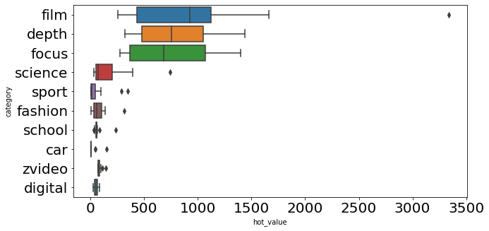

```python
plt.figure(figsize=(10,5))
sns.boxplot(x='hot_value',y='category',data=itemdf)
plt.tick_params(labelsize=20)
```

总结： 目前上热榜的题目中，时事、国际、电影 三个类型占到了最多的热榜且最火热；汽车板块的热度最低。

```python
bins = [0,50,200,500,1000,2000]
itemdf['hot_rank'] = pd.cut(itemdf['hot_value'],bins,right=False)
itemdf.groupby(itemdf['hot_rank']).hot_value.describe()
```

| hot_rank | count | mean | std | min | 25% | 50% | 75% | max |
| --- | --- | --- | --- | --- | --- | --- | --- | --- |
| [0, 50) | 47.0 | 23.638298 | 17.093637 | 6.0 | 6.0 | 25.0 | 41.50 | 49.0 |
| [50, 200) | 50.0 | 82.040000 | 30.373162 | 54.0 | 59.0 | 73.0 | 89.25 | 176.0 |
| [200, 500) | 21.0 | 329.857143 | 60.228968 | 231.0 | 288.0 | 340.0 | 364.00 | 480.0 |
| [500, 1000) | 15.0 | 760.266667 | 161.855521 | 530.0 | 626.0 | 756.0 | 919.50 | 959.0 |
| [1000, 2000) | 14.0 | 1255.000000 | 208.497925 | 1025.0 | 1086.5 | 1185.0 | 1387.00 | 1660.0 |

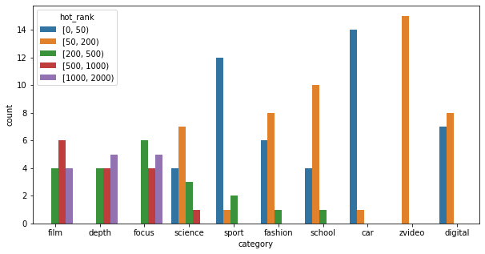

```python
plt.figure(figsize=(10,5))
sns.countplot(x='category',hue='hot_rank',data=itemdf)
# 纵坐标是热度 不是排行
```

## 爬取某一问题内的回答

```python
question_df = pd.read_csv('question_sample_zhihu.csv')
```

```python
qdf = question_df.sort_values(by='web-scraper-order')
```

```python
qdf.columns
```

```
Index(['web-scraper-order', 'web-scraper-start-url', 'user_name', 'post_tiime',
       'like', 'comment', 'body', 'user_quote'],
      dtype='object')
```

```python
qdf_new = pd.DataFrame(columns = [])
for col in list(qdf.columns):
    qdf[col]=qdf[col].dropna().reset_index(drop=True)
    qdf_new = pd.concat([qdf_new,qdf[col]],axis=1)
```

```python
qdf_new=qdf_new.sort_values(by='body').reset_index(drop=True)[0:30].drop(['web-scraper-order','web-scraper-start-url'],axis=1)
```

```python
qdf_new
```

|  | user_name | post_tiime | like | comment | body | user_quote |
| --- | --- | --- | --- | --- | --- | --- |
| 0 | Stan Moon | 编辑于 2018-11-15 | 赞同 2.2K | 442 条评论 | 1，配音，不是一次两次出戏了，稍微了解日漫的人会知道，日漫配音跟他们生活中的说话方式是很大不... | 微信公众号：“营养泡面”。 |
| 1 | NaN | 编辑于 2018-08-09 | 赞同 1K | 429 条评论 | mdzs粉丝自称国漫之光的时候8.9更新常规操作了<img src="https://pic... | NaN |
| 2 | 文狸 | 编辑于 2018-09-08 | 赞同 89 | 38 条评论 | 一个行业的兴衰，与教育是离不开的。你学动画，而你并不热爱它，只是为了混口饭吃。对于你一个来说... | 一朵水性杨花 |
| 3 | NaN | 编辑于 22:25 | 赞同 129 | 26 条评论 | 不会完！！不会完！！而且会越来越好。题目可以改为“有没有没有那个瞬间觉得国产动画会越来越好”... | NaN |
| 4 | 利兰海 | 编辑于 2019-04-22 | 赞同 1.6K | 147 条评论 | 不知不觉中成了本人知乎第一个过千赞的回答呢，真的是谢谢诸位的厚爱。\n有些人从各种角度dis... | 学生 |
| 5 | NaN | 编辑于 2020-02-09 | 赞同 319 | 50 条评论 | 中国动画产业完了？\n不存在的\n只要有迪士尼、皮克斯的动画电影上映，经常会引起一阵对于国产... | NaN |
| 6 | 叉少 | 编辑于 2020-01-13 | 赞同 18K | 1,166 条评论 | 二十世纪六十年代，乔布斯还是少年，世界范围内还没有一台手机，东京的地铁上却已经有了第一批低头... | 公众号「 叉烧往事 」主理人 |
| 7 | 锦兮 | 编辑于 2019-05-17 | 赞同 165 | 20 条评论 | 作为一个每天苦逼K动画的动画师 看到这个问题百感交集 其实我们也很想把东西... | 电影即是人生 |
| 8 | 江风 | 编辑于 2018-07-26 | 赞同 1.4K | 259 条评论 | 关于评论区的更新同样的道理当然可以用在日漫痴，美漫痴的身上啦。毕竟我的灵感就是来自于某个讨论... | 是要就此消沉，还是站起来。 |
| 9 | 回锅淋油棒棒鸡 | 编辑于 2018-10-18 | 赞同 96 | 31 条评论 | 凸变英雄leaf，前几集还不错，甚至可以说出彩，不知道从第六集还是第七集开始剧情就很迷了，明... | there can be miracle when you believe |
| 10 | 搓脚的诗人 | 编辑于 2018-08-23 | 赞同 80 | 13 条评论 | 刚刚入行的时候，看到乱七八糟的分工，毫无规范的流程，错字连篇的剧本，小学学历的导演，就觉得药... | 这里有一些私货，请查收哦 【公众号：阿牧的观察镜】 |
| 11 | 唐明 | 编辑于 15:27 | 赞同 9.6K | 1,349 条评论 | 前言：不用看了，知乎热榜的右图在我这。(づ￣ ³￣)づ，拿去吧。角色出自什么动画我下面的回答... | 赛博朋克2077跳票了（微笑 |
| 12 | 嫏嬛 | 编辑于 2018-07-30 | 赞同 926 | 162 条评论 | 哇知乎小透明突然发现这么多赞啦！那我把狐妖87集的吐槽也从贴吧搬运过来吧(反正是我写的)《狐... | 业余动画爱好者 |
| 13 | Ricardo | 编辑于 2018-10-15 | 赞同 156 | 24 条评论 | 哪个瞬间……这个也不太好说，从15年开始，15.16.17每一年的暑假都有一部大字开头的动画... | 绿怪研/动画的修行者 |
| 14 | NaN | 发布于 2018-10-21 | 赞同 138 | 45 条评论 | 大概是这几年少儿频道一直重播以前的剪纸动画，禁了一些具有“暴力倾向”的动画，（说真的，禁《虹... | NaN |
| 15 | lqfewe | 编辑于 2018-07-22 | 赞同 243 | 29 条评论 | 学校教学划水，学生基本功不好，没有努力方向，不知道如何踏足行业。\n产业链不够完善，国家重视... | 一介俗人 |
| 16 | Buster | 编辑于 2018-10-14 | 赞同 2.6K | 764 条评论 | 小时候少儿频道放的动画都是《神厨小福贵》《虹猫蓝兔七侠传》《小鲤鱼历险记》 《中华小子》《神... | 禅伏诗魔归净域，酒冲愁阵出奇兵。 |
| 17 | NaN | 发布于 00:44 | 赞同 693 | 105 条评论 | 当年哔哩哔哩怎么吹异常生物见闻录的时候我记得清清楚楚。国产全资。B站首部自制。风传投资五千万... | NaN |
| 18 | 莓朵 | 编辑于 2018-08-09 | 赞同 1.4K | 320 条评论 | 当领导来我们公司视察的时候，领导说动画在题材这一块很重要。我们上级献媚说：对，我们中国动画就... | B站UP主：乐观的小瑞 |
| 19 | NaN | 发布于 2018-09-11 | 赞同 130 | 20 条评论 | 我个人觉得，抛开政策问题，最让我心寒的是部分（好吧我就直说了，是绝大部分）国漫粉的无脑吹国漫... | NaN |
| 20 | 外向的孤独患者 | 发布于 2020-02-16 | 赞同 3.6K | 323 条评论 | 我也奇怪了，在我七八岁的时候，我看宠物小精灵，看数码暴龙1(翡翠台)，我也看的懂啊，也能理解... | 可能是知乎最多干货的写手 |
| 21 | 每一天欢乐 | 编辑于 2018-12-05 | 赞同 3K | 255 条评论 | 我真的不觉得国漫药丸。我想单独拎出来配音演员这一个话题，因为真的很不忍心看到某些回答里面把各... | 温柔肥宅，宅心人厚。 |
| 22 | 阿牧的观察镜 | 发布于 2018-09-07 | 赞同 1.4K | 160 条评论 | 我至今记得《雷锋的故事》带给我的深深的震撼。第一二集我几乎在惊呆着闭不了嘴的状态下看完的。。... | 约稿请加微信KKKZ5243 |
| 23 | Bais | 编辑于 2018-10-02 | 赞同 1.1K | 255 条评论 | 有妖气，有妖气网站，有妖7。是不是脑子有泡？有没有点运营思维？会员按月卖吗？还有其他各种漫画... | 自说自话的本事不小 |
| 24 | 李辉泉 | 编辑于 2018-10-16 | 赞同 10K | 4,101 条评论 | 有观点我欢迎一起在评论区讨论，不要回答没看完，就给我怼，不要再败坏作品好感度了（严肃）( ˙... | I'm tired.So tired. |
| 25 | ella | 发布于 2018-08-31 | 赞同 83 | 5 条评论 | 浏览了答案，真是负能量满满啊。中国动画产业什么时候真的完了，我真不知道，但在制作现场里，你总... | NaN |
| 26 | NaN | 编辑于 2020-01-07 | 赞同 3K | 928 条评论 | 看下面的图片，如果不加名字大家能区分出这些动漫吗？各种网红脸加修真小说改编。我觉得一个成功的... | NaN |
| 27 | 希斯特贝尔金 | 发布于 2018-05-24 | 赞同 458 | 31 条评论 | 瞬间？ | 准码农 |
| 28 | 狐小寻 | 编辑于 2018-06-08 | 赞同 4.7K | 275 条评论 | 说一个去年在苏州某动画公司做制片的经历。客户是国内某零食品牌，准备做一个系列的电视动画，分了... | 快乐就好 |
| 29 | 妄言阿卿 | 编辑于 2018-07-28 | 赞同 230 | 23 条评论 | 说实话，作为观众而言， 现在的中国动画产业还真不算让人感觉药丸。真让我感觉药丸的是当年《我为... | 没错！我就是极皮动物！ |

### 数据清洗

#### 提取数值型数据

##### 点赞数

```python
qdf_new['like'] = qdf_new['like'].str.replace('赞同','')
```

```python
for index in list(qdf_new['like'].index):
    if '.' in qdf_new['like'][index]:
        qdf_new['like'][index] = qdf_new['like'][index].replace('K','00')
        qdf_new['like'][index] = qdf_new['like'][index].replace('.','')
    elif 'K' in qdf_new['like'][index]:
        qdf_new['like'][index] = qdf_new['like'][index].replace('K','000')
```

```python
qdf_new['like'].sample().iloc[0]
```

```
'\u200b 3000'
```

```python
qdf_new['like']=qdf_new['like'].str.replace('\u200b','')
```

```python
qdf_new['like']=qdf_new['like'].astype(int)
```

##### 评论数

```python
qdf_new['comment'] = qdf_new['comment'].str.split(' ').str[0]
```

```python
qdf_new['comment']=qdf_new['comment'].str.replace('条评论','').str.replace(',','')
```

```python
qdf_new['comment']=qdf_new['comment'].str.replace('\u200b','').astype(int)
```

#### 回答中包含图片的数量

```python
qdf_new['images']=qdf_new['body'].apply(lambda x: x.count('<img'))
```

#### 回答包含字符数

```python
qdf_new['body_character'] = qdf_new['body'].apply(lambda x: len(x))
```

#### 答案是否编辑

```python
qdf_new.columns
```

```
Index(['user_name', 'post_tiime', 'like', 'comment', 'body', 'user_quote',
       'images', 'body_character'],
      dtype='object')
```

```python
qdf_new.columns = ['user_name', 'post_time', 'like', 'comment', 'body', 'user_quote',
       'images', 'body_character']
```

```python
qdf_new['whether_edit'] = qdf_new['post_time'].str[:2].apply(lambda x: 1 if x== '编辑' else 0)
```

#### 提取时间

```python
qdf_new['post_time'] = qdf_new['post_time'].str.split(' ').str[-1]
```

```python
qdf_new['post_hour'] = pd.to_datetime(qdf_new['post_time']).dt.hour
```

### 分析及可视化 高赞回答特征

```python
import seaborn as sns
import matplotlib.pyplot as plt

plt.rcParams['font.sans-serif']=['simhei']
plt.rcParams['axes.unicode_minus']=False

%matplotlib inline
```

#### 点赞数

```python
qdf_new['like'].describe()
```

```
count       30.000000
mean      2284.500000
std       3880.932893
min         80.000000
25%        158.250000
50%        963.000000
75%       2500.000000
max      18000.000000
Name: like, dtype: float64
```

```
findfont: Font family ['sans-serif'] not found. Falling back to DejaVu Sans.
```

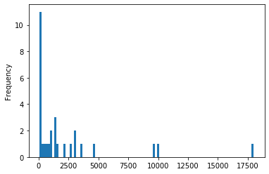

```python
qdf_new['like'].plot(kind='hist',bins=100)
```

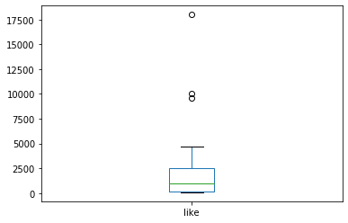

```python
qdf_new['like'].plot(kind='box')
```

绝对大多数的获赞数都在5000以下，10000与17500的获赞数是离群值。

```python
# ratio of those the answer with 0 like
(qdf_new['like']==0).sum()/qdf_new.shape[0]
```

```
0.0
```

没有一个回答是0个赞的。

```python
# ratio of the amount of likes from the one with the most
qdf_new['like'].max()/qdf_new['like'].sum()
```

```
0.262639527248851
```

最多赞的单个评论所获的赞，占据了总点赞数的26%。

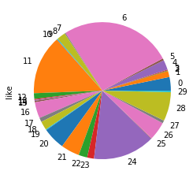

```python
qdf_new['like'].plot(kind='pie')
```

#### 评论数

```python
qdf_new['comment'].describe()
```

```
count      30.000000
mean      393.166667
std       782.566779
min         5.000000
25%        29.500000
50%       153.500000
75%       322.250000
max      4101.000000
Name: comment, dtype: float64
```

```python
# ratio of those the answer with 0 comment
(qdf_new['comment']==0).sum()/qdf_new.shape[0]
```

```
0.0
```

没有一个回答是0评论的。

```python
# ratio of the amount of comment from the one with the most
qdf_new['comment'].max()/qdf_new['comment'].sum()
```

```
0.3476896990250106
```

最多评论的回答所获得的评论是总评论数的34.8%。

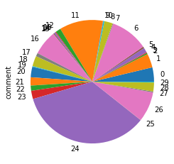

```python
qdf_new['comment'].plot(kind='pie')
```

#### 图片数量

```python
qdf_new['images'].describe()
```

```
count     30.000000
mean      11.333333
std       30.751881
min        0.000000
25%        0.000000
50%        0.000000
75%        3.000000
max      130.000000
Name: images, dtype: float64
```

```python
(qdf_new['images']>0).sum()
```

```
14
```

有放照片的回答有14个。

```python
qdf_new[['images','like','comment']].corr()
```

|  | images | like | comment |
| --- | --- | --- | --- |
| images | 1.000000 | 0.360847 | 0.186197 |
| like | 0.360847 | 1.000000 | 0.672575 |
| comment | 0.186197 | 0.672575 | 1.000000 |

照片数量与获赞数、评论数之间 没有非常强的关联。

#### 是否二次编辑

```python
# proportion of those edited
qdf_new['whether_edit'].mean()
```

```
0.7666666666666667
```

```python
#the data within those edited
qdf_new[qdf_new['whether_edit']==1][['like','comment']].describe()
```

|  | like | comment |
| --- | --- | --- |
| count | 23.000000 | 23.000000 |
| mean | 2697.086957 | 482.869565 |
| std | 4319.062029 | 876.205627 |
| min | 80.000000 | 13.000000 |
| 25% | 197.500000 | 30.000000 |
| 50% | 1100.000000 | 255.000000 |
| 75% | 2800.000000 | 435.500000 |
| max | 18000.000000 | 4101.000000 |

编辑过的回答，平均获得2697个赞和483评论。

```python
#the data without those edited
qdf_new[qdf_new['whether_edit']==0][['like','comment']].describe()
```

|  | like | comment |
| --- | --- | --- |
| count | 7.000000 | 7.000000 |
| mean | 928.857143 | 98.428571 |
| std | 1265.794669 | 112.951106 |
| min | 83.000000 | 5.000000 |
| 25% | 134.000000 | 25.500000 |
| 50% | 458.000000 | 45.000000 |
| 75% | 1046.500000 | 132.500000 |
| max | 3600.000000 | 323.000000 |

没有编辑过的回答，平均928个赞和98个评论。

```python
def double_edit_plot(col_name):
    yes = pd.DataFrame(qdf_new[qdf_new['whether_edit'] == 1][col_name].describe()).reset_index()
    yes['whether_edit'] = '是'
    yes = yes.reset_index(drop=True)

    no = pd.DataFrame(qdf_new[qdf_new['whether_edit'] == 0][col_name].describe()).reset_index()
    no['whether_edit'] = '否'
    no = no.reset_index(drop=True)

    data = yes.append(no).reset_index(drop=True)

    sns.barplot(x='index',y=col_name,data=data,hue='whether_edit');
#     return data
```

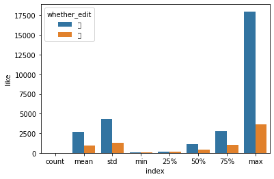

```python
double_edit_plot('like')
```

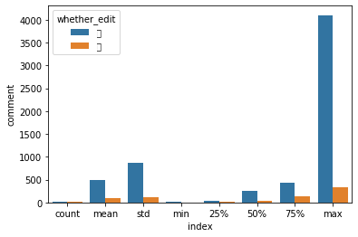

```python
double_edit_plot('comment')
```

#### 发布时间

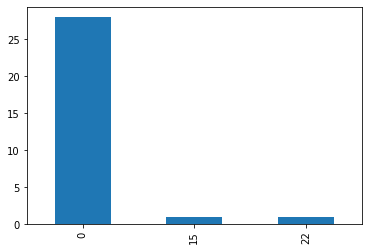

```python
qdf_new['post_hour'].value_counts().sort_index().plot(kind='bar');
```

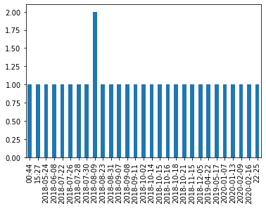

```python
qdf_new['post_time'].value_counts().sort_index().plot(kind='bar');
```

#### 字符数

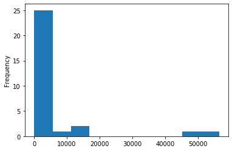

```python
qdf_new['body_character'].plot(kind='hist')
```

绝大多的回答的字符数少于一万字。

### 相关性

```python
qdf_new.columns
```

```
Index(['user_name', 'post_time', 'like', 'comment', 'body', 'user_quote',
       'images', 'body_character', 'whether_edit', 'post_hour'],
      dtype='object')
```

```python
qdf_new[['like','comment','images','body_character']].corr()
```

|  | like | comment | images | body_character |
| --- | --- | --- | --- | --- |
| like | 1.000000 | 0.672575 | 0.360847 | 0.398238 |
| comment | 0.672575 | 1.000000 | 0.186197 | 0.199148 |
| images | 0.360847 | 0.186197 | 1.000000 | 0.997526 |
| body_character | 0.398238 | 0.199148 | 0.997526 | 1.000000 |

字符数与是否插入图片有很强的关联。

### 爬取回答内容 + 分词

```python
import jieba
import collections
```

```python
import re
def find_chinese(file):
    pattern = re.compile(r'[^\u4e00-\u9fa5]')
    chinese = re.sub(pattern, '', file)
    return chinese
```

```python
results1=[]
def get_words_num(temp):
    seg_list = jieba.cut(find_chinese(temp))
    seg_string = ", ".join(seg_list)
    results = seg_string.split(',')
    for i in range(len(results)):
        if len(results[i]) > 2:
            results1.append(results[i])
    results_dict = dict(collections.Counter(results1))
    #按照value进行排序
    results_dict = {k: v for k, v in sorted(results_dict.items(), key=lambda item: item[1], reverse=True)}
    #筛选前十个
    return({item[0]:item[1] for i,item in enumerate(results_dict.items()) if i < 100})
```

```python
#把所有评论的中文提取出来放在一起
body_list = ''
n = 0
while n < qdf_new['body'].size:
    body_list = body_list + find_chinese(qdf_new['body'][n])
    n = n +1
```

```python
get_words_num(body_list)
```

[output not shown]

```
{' 动画': 396,
 ' 国产': 109,
 ' 中国': 106,
 ' 一个': 102,
 ' 日本': 88,
 ' 自己': 86,
 ' 作品': 86,
 ' 我们': 80,
 ' 什么': 77,
 ' 没有': 74,
 ' 就是': 71,
 ' 不是': 61,
 ' 觉得': 61,
 ' 制作': 61,
 ' 这个': 59,
 ' 他们': 56,
 ' 真的': 55,
 ' 知道': 53,
 ' 动漫': 52,
 ' 可以': 52,
 ' 国漫': 51,
 ' 这样': 50,
 ' 现在': 49,
 ' 问题': 49,
 ' 因为': 49,
 ' 公司': 49,
 ' 故事': 47,
 ' 但是': 44,
 ' 剧情': 43,
 ' 开始': 41,
 ' 看到': 40,
 ' 这些': 37,
 ' 所以': 37,
 ' 其实': 35,
 ' 世界': 35,
 ' 还有': 34,
 ' 你们': 33,
 ' 回答': 33,
 ' 出来': 33,
 ' 漫画': 33,
```

[output cut: 45 more lines]

```
 ' 过去': 21,
 ' 一部': 21,
 ' 票房': 21,
 ' 存在': 20,
 ' 大鱼': 20,
 ' 出品': 20,
 ' 某些': 20,
 ' 有些': 19,
 ' 不要': 19,
 ' 崛起': 19,
 ' 更新': 19,
 ' 下面': 19,
 ' 当年': 19,
 ' 确实': 19,
 ' 万籁鸣': 19}
```

```python
wordstring = ''
for key in get_words_num(body_list):
    wordstring = wordstring + key
```

```python
wordstring
```

```
' 动画 国产 中国 一个 日本 自己 作品 我们 什么 没有 就是 不是 觉得 制作 这个 他们 真的 知道 动漫 可以 国漫 这样 现在 问题 因为 公司 故事 但是 剧情 开始 看到 这些 所以 其实 世界 还有 你们 回答 出来 漫画 题材 时间 时候 产业 发展 还是 这种 喜欢 这么 导演 很多 日漫 配音 可能 已经 虽然 人物 那么 应该 怎么 一些 观众 市场 一下 只是 如果 而且 不过 最后 几个 评论 电影 水准 评分 有人 行业 作为 类型 方面 比如 甚至 这里 不能 各种 质量 过去 一部 票房 存在 大鱼 出品 某些 有些 不要 崛起 更新 下面 当年 确实 万…
```

```python
pip install wordcloud
```

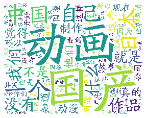

```python
from matplotlib import pyplot as plt
from wordcloud import WordCloud

font = r'/Users/apple/Library/Fonts/FZBWKSK.TTF'
wc = WordCloud(font_path=font, #如果是中文必须要添加这个，否则会显示成框框
               background_color='white',
               width=5000,
               height=4000,
               ).generate(wordstring)
wc.to_file('ss.png') #保存图片
plt.imshow(wc)  #用plt显示图片
plt.axis('off') #不显示坐标轴
plt.show() #显示图片
```